# Data Science Toolchain with Spark and R

## Model

The goal of a model is to provide a simple low-dimensional summary of a dataset. Ideally, the model will capture true *signals* (i.e. patterns generated by the phenomenon of interest), and ignore *noise* (i.e. random variation that you are not interested in).

## Model Data

Create a model dataset for trips from Turtle Bay-East Midtown to JFK airport. Impose cutoffs cutoffs and break the data int test and training partitions. Cache the tables in order to improve performance of modeling techniques.

```r
# Select a model data set
model_tbl <- trips_model_data_tbl %>%
  filter(fare_amount > 0 & fare_amount < 100) %>%
  filter(tip_amount >= 0 & tip_amount < 25) %>%
  filter(passenger_count > 0 & passenger_count < 5) %>%
  filter(pickup_nta == "Turtle Bay-East Midtown" & dropoff_nta == "Airport") %>%
  select(tip_amount, fare_amount, pay_type, passenger_count)
# Partitioin into train and validate
model_partition_tbl <- model_tbl %>%
  sdf_partition(train = 0.1, test = 0.1, seed = 4321)
# Create table references
trips_train_tbl <- sdf_register(model_partition_tbl$train, "trips_train")
trips_test_tbl <- sdf_register(model_partition_tbl$test, "trips_test")
# Cache
tbl_cache(sc, "trips_train")
tbl_cache(sc, "trips_test")
```

## Train ML model

Build a simple linear regression using Spark ML. Use standard R formulas with Spark ML. Notice that people who pay with credit pay significantly more on average than people who pay in cash.

```r
model_formula <- formula(tip_amount ~ fare_amount + pay_type + passenger_count)
m1 <- ml_linear_regression(trips_train_tbl, model_formula)
```

```
* No rows dropped by 'na.omit' call
```

```r
summary(m1)
```

```
Call: ml_linear_regression(trips_train_tbl, model_formula)

Deviance Residuals: (approximate):
     Min       1Q   Median       3Q      Max
-10.8908  -1.1683   0.2492   1.0044  17.8987

Coefficients:
                   Estimate  Std. Error  t value  Pr(>|t|)
(Intercept)     -3.01208943  0.00897093 -335.761 < 2.2e-16 ***
fare_amount      0.09487781  0.00020317  466.981 < 2.2e-16 ***
pay_type_credit  6.96537004  0.00475925 1463.544 < 2.2e-16 ***
pay_type_unk     1.52828760  0.04278342   35.721 < 2.2e-16 ***
passenger_count -0.08913682  0.00349172  -25.528 < 2.2e-16 ***
---
Signif. codes:  0 ‘***’ 0.001 ‘**’ 0.01 ‘*’ 0.05 ‘.’ 0.1 ‘ ’ 1

R-Squared: 0.7122
Root Mean Squared Error: 2.267
```

### Test ML model

Score the model using `sdf_predict`. Plot the residuals to evaluate model assumptions.

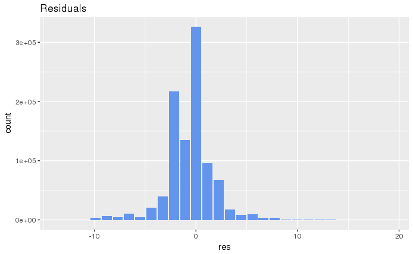

```r
# Score the predictions
pred_ml_tbl <- sdf_predict(m1, trips_test_tbl)
pred_ml_tbl %>%
  mutate(res = tip_amount - prediction) %>%
  sqlvis_compute_histogram("res") %>%
  sqlvis_ggplot_histogram(title = "Residuals")
```

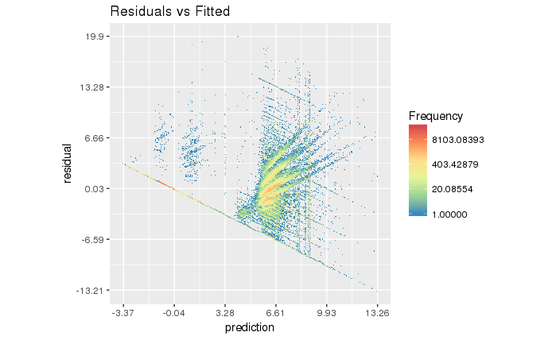

```r
pred_ml_tbl %>%
  mutate(residual = tip_amount - prediction) %>%
  sqlvis_compute_raster("prediction", "residual") %>%
  sqlvis_ggplot_raster(title = "Residuals vs Fitted")
```

## H2O Model

Use `rsparkling` to convert Spark DataFrames to H2O Frames. Use H2O to fit a linear model.

```r
# Convert to H2O Frames
trips_train_h2o_tbl <- as_h2o_frame(sc, trips_train_tbl)
trips_test_h2o_tbl <- as_h2o_frame(sc, trips_test_tbl)
# Format H2O Frames
trips_train_h2o_tbl$pay_type <- as.factor(trips_train_h2o_tbl$pay_type)
trips_test_h2o_tbl$pay_type <- as.factor(trips_test_h2o_tbl$pay_type)
# Fit model on H2O train data
m2 <- h2o.glm(
  x = c("fare_amount", "pay_type", "passenger_count"),
  y = "tip_amount",
  trips_train_h2o_tbl,
  alpha = 0,
  lambda = 0
  )
summary(m2)
```

```
Model Details:
==============

H2ORegressionModel: glm
Model Key:  GLM_model_R_1486697804838_5
GLM Model: summary
    family     link regularization number_of_predictors_total number_of_active_predictors
1 gaussian identity           None                          4                           4
  number_of_iterations  training_frame
1                    0 RTMP_sid_9f0e_5

H2ORegressionMetrics: glm
** Reported on training data. **

MSE:  5.138877
RMSE:  2.266909
MAE:  1.606482
RMSLE:  NaN
Mean Residual Deviance :  5.138877
R^2 :  0.7121581
Null Deviance :17439933
Null D.o.F. :976855
Residual Deviance :5019943
Residual D.o.F. :976851
AIC :4371161





Scoring History:
            timestamp   duration iteration negative_log_likelihood objective
1 2017-02-10 04:35:49  0.000 sec         0          17439932.71886  17.85313

Variable Importances: (Extract with `h2o.varimp`)
=================================================

Standardized Coefficient Magnitudes: standardized coefficient magnitudes
            names coefficients sign
1 pay_type.credit     6.965370  POS
2    pay_type.unk     1.528288  POS
3     fare_amount     1.072590  POS
4 passenger_count     0.058928  NEG
```

## H2O deep learning

Fit a model using H2O’s deep learning algorithm.

```r
m3 <- h2o.deeplearning(
  x = c("fare_amount", "pay_type", "passenger_count"),
  y = "tip_amount",
  training_frame = trips_train_h2o_tbl,
  epochs = 2,
  seed = 999
  )
summary(m3)
```

```
Model Details:
==============

H2ORegressionModel: deeplearning
Model Key:  DeepLearning_model_R_1486697804838_6
Status of Neuron Layers: predicting tip_amount, regression, gaussian distribution, Quadratic loss, 41,801 weights/biases, 497.9 KB, 3,566,136 training samples, mini-batch size 1
  layer units      type dropout       l1       l2 mean_rate rate_rms momentum mean_weight
1     1     6     Input  0.00 %
2     2   200 Rectifier  0.00 % 0.000000 0.000000  0.202868 0.375130 0.000000   -0.033168
3     3   200 Rectifier  0.00 % 0.000000 0.000000  0.222792 0.223573 0.000000   -0.031459
4     4     1    Linear         0.000000 0.000000  0.003968 0.006017 0.000000    0.002373
  weight_rms mean_bias bias_rms
1
2   0.199669  0.299779 0.130903
3   0.080849  0.874672 0.060350
4   0.036086  0.887398 0.000000

H2ORegressionMetrics: deeplearning
** Reported on training data. **
** Metrics reported on temporary training frame with 9987 samples **

MSE:  4.595854
RMSE:  2.143794
MAE:  1.267261
RMSLE:  0.4299244
Mean Residual Deviance :  4.595854





Scoring History:
            timestamp   duration training_speed  epochs iterations        samples
1 2017-02-10 04:35:50  0.000 sec                0.00000          0       0.000000
2 2017-02-10 04:35:52  1.787 sec 216396 obs/sec 0.22795          1  222672.000000
3 2017-02-10 04:35:57  6.898 sec 585284 obs/sec 3.65063          5 3566136.000000
  training_rmse training_deviance training_mae
1
2       2.37281           5.63024      1.80343
3       2.14379           4.59585      1.26726
```

## Collect into R

Model in R. Notice the modeling dataset is only 1 million records, a small fraction of the overall data. It isn’t unusual for model data to be orders of magnitude smaller than input data.

```r
# Check number of rows
nrow(trips_train_tbl)
```

```
[1] 976856
```

Collect the data into R and build a linear model and a regression tree using traditional R techniques.

```r
# Collect
trips_train <- collect(trips_train_tbl)
trips_test <- collect(trips_test_tbl)
# Format factors
trips_train$pay_type <- as.factor(trips_train$pay_type)
trips_test$pay_type <- as.factor(trips_test$pay_type)
# Fit linear model
m4 <- glm(model_formula, data = trips_train)
summary(m4)
```

```
Call:
glm(formula = model_formula, data = trips_train)

Deviance Residuals:
     Min        1Q    Median        3Q       Max
-13.0673   -1.1683    0.2544    1.0044   20.3593

Coefficients:
                  Estimate Std. Error t value Pr(>|t|)
(Intercept)     -3.0120894  0.0089709 -335.76   <2e-16 ***
fare_amount      0.0948778  0.0002032  466.98   <2e-16 ***
pay_typecredit   6.9653700  0.0047592 1463.55   <2e-16 ***
pay_typeunk      1.5282876  0.0427834   35.72   <2e-16 ***
passenger_count -0.0891368  0.0034917  -25.53   <2e-16 ***
---
Signif. codes:  0 ‘***’ 0.001 ‘**’ 0.01 ‘*’ 0.05 ‘.’ 0.1 ‘ ’ 1

(Dispersion parameter for gaussian family taken to be 5.138903)

    Null deviance: 17439933  on 976855  degrees of freedom
Residual deviance:  5019943  on 976851  degrees of freedom
AIC: 4371161

Number of Fisher Scoring iterations: 2
```

```r
# Regression tree
library(rpart)
m5 <- rpart(model_formula, trips_train)
summary(m5)
```

```
Call:
rpart(formula = model_formula, data = trips_train)
  n= 976856

          CP nsplit rel error    xerror         xstd
1 0.64751883      0 1.0000000 1.0000020 0.0012057739
2 0.08150763      1 0.3524812 0.3524821 0.0008185793
3 0.01325840      2 0.2709735 0.2709753 0.0007414644
4 0.01280029      3 0.2577151 0.2577206 0.0007433468
5 0.01000000      4 0.2449148 0.2449216 0.0007430512

Variable importance
   pay_type fare_amount
         85          15

Node number 1: 976856 observations,    complexity param=0.6475188
  mean=4.350597, MSE=17.85313
  left son=2 (372246 obs) right son=3 (604610 obs)
  Primary splits:
      pay_type        splits as  LRL,        improve=0.647518800, (0 missing)
      fare_amount     < 26.985 to the left,  improve=0.066003490, (0 missing)
      passenger_count < 1.5    to the right, improve=0.006762336, (0 missing)
  Surrogate splits:
      fare_amount     < 18.795 to the left,  agree=0.623, adj=0.012, (0 split)
      passenger_count < 3.5    to the right, agree=0.621, adj=0.005, (0 split)

Node number 2: 372246 observations
  mean=0.01742485, MSE=0.1360449

Node number 3: 604610 observations,    complexity param=0.08150763
  mean=7.018443, MSE=10.08353
  left son=6 (388518 obs) right son=7 (216092 obs)
  Primary splits:
      fare_amount     < 32.95  to the left,  improve=2.331605e-01, (0 missing)
      passenger_count < 1.5    to the right, improve=2.683454e-06, (0 missing)

Node number 6: 388518 observations,    complexity param=0.01280029
  mean=5.874913, MSE=4.440989
  left son=12 (221699 obs) right son=13 (166819 obs)
  Primary splits:
```

[output cut: 8 more lines]

```
      passenger_count < 1.5    to the right, improve=0.0007323981, (0 missing)
  Surrogate splits:
      passenger_count < 2.5    to the left,  agree=0.506, adj=0.003, (0 split)

Node number 12: 221699 observations
  mean=5.21738, MSE=3.438715

Node number 13: 166819 observations
  mean=6.748761, MSE=4.434795

Node number 14: 109082 observations
  mean=8.049876, MSE=9.850696

Node number 15: 107010 observations
  mean=10.11882, MSE=15.36263
```

## Compare models

Compare the following models:

- Spark ML linear model
- H2O linear model
- R linear model
- H2O deep learning
- R regression tree

```r
# Score H2O test data
prediction_m2 <- h2o.predict(m2, newdata = trips_test_h2o_tbl)
prediction_m3 <- h2o.predict(m3, newdata = trips_test_h2o_tbl)
pred_h2o <- data.frame(
  tip_amount = trips_test$tip_amount,
  as_spark_dataframe(sc, prediction_m2),
  as_spark_dataframe(sc, prediction_m3)
)
# Score other models
trips_test$pred_lm <- predict(m4, trips_test)
trips_test$pred_rpart <- predict(m5, trips_test)
# Compute the mean squared error
mse <- function(formula, data) {
  data %>%
    mutate_(residual = formula) %>%
    summarize(mse = mean(residual ^ 2)) %>%
    collect %>%
    .[["mse"]]
}
# Summary
out <- data.frame(
  Train = c(
    ML_glm = m1$mean.squared.error,
    H2O_glm = h2o.mse(m2),
    H2O_deeplearning = h2o.mse(m3),
    R_glm = mean(m4$residuals^2),
    R_rpart = mean(resid(m5)^2)
    ),
  Test = c(
    ML_glm = mse(~ tip_amount - prediction, pred_ml_tbl),
    H2O_glm = mse(~ tip_amount - predict, pred_h2o),
    H2O_deeplearning = mse(~ tip_amount - predict.1, pred_h2o),
    R_glm = mse(~ tip_amount - pred_lm, trips_test),
    R_rpart = mse(~ tip_amount - pred_rpart, trips_test)
    )
  )
out
```

|  | Train | Test |
| --- | --- | --- |
| ML_glm | 5.138877 | 5.146262 |
| H2O_glm | 5.138877 | 5.146262 |
| H2O_deeplearning | 4.595854 | 4.315740 |
| R_glm | 5.138877 | 5.146262 |
| R_rpart | 4.372496 | 4.386431 |

# Communicate

After controlling for fare amount, we found that trips paying with cash tip less on average than trips paying with credit. Additionally, trips with more passengers tend to tip less.

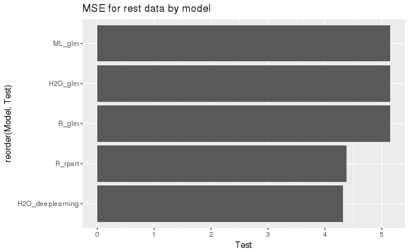

```r
out %>%
  mutate(Model = rownames(out)) %>%
  ggplot(aes(x = reorder(Model, Test), y = Test)) +
  geom_bar(stat = "Identity") +
  coord_flip() +
  ggtitle("MSE for rest data by model")
```